# **Interpretation Charts für Report / Dashboard**

### Top 10 Materialien mit den meisten verspäteten Lieferungen

**Interpretation** Diese Materialien sind besonders kritisch für die Lieferkette und könnten Produktionsstopps verursachen. Solche Verzögerungen können auf Engpässe bei den Lieferanten oder ineffiziente Logistik hinweisen.

**Handlungsempfehlung** Lieferketten überprüfen und alternative Lieferanten für problematische Materialien evaluieren. Alternative Beschaffungsquellen prüfen, um Abhängigkeiten zu reduzieren.

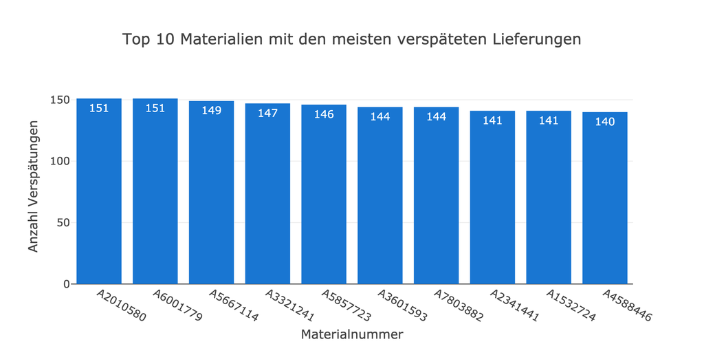

```python
display(Image(filename="../reports/images/top_10_verspätungen_bar.png", width=600, height=200))
```

### Lieferperformance Top 10 - Kritische Lieferanten

Die Grafik zeigt die Liefertreue der 10 kritischsten Lieferanten in den letzten 6 Monaten. Es wird deutlich, dass einige Lieferanten stärkere Schwankungen aufweisen.

**Handlungsempfehlung** Schwankende Lieferanten priorisiert überprüfen und gezielt Unterstützungsmaßnahmen oder Alternativen evaluieren.

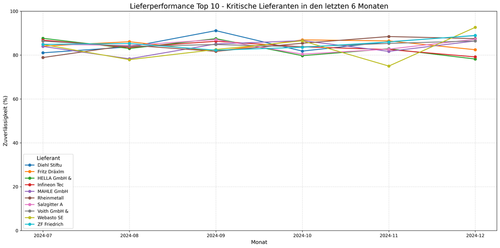

```python
display(Image(filename="../reports/images/top10_lieferperformance_linie.png", width=600, height=200))
```

### Top 10 Lieferanten mit den höchsten Anteilen verspäteter Lieferungen

**Interpretation** Lieferanten mit hohen Verspätungsraten stellen ein Risiko für die Lieferkette dar. Potenziell systemische Probleme bei diesen Lieferanten könnten eine Ursache sein.

**Handlungsempfehlung** Maßnahmen priorisieren, wie regelmäßige Überwachung und Einführung von KPIs. Notfalls Lieferanten mit besseren Liefertreuewerten auswählen.

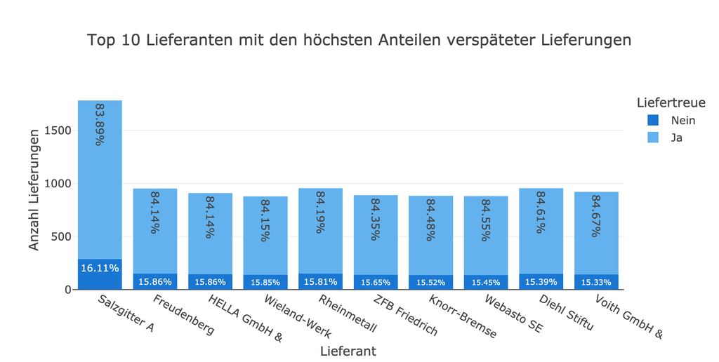

```python
display(Image(filename="../reports/images/top10_liefertreuen_bar.png", width=600, height=200))
```

### Top 10 Lieferanten basierend auf Mengenabweichungen (Ist vs. Soll)

**Interpretation** Große Abweichungen können Produktionsprobleme oder schlechte Bestandsplanung verursachen. LEONI AG und Salzgitter A zeigen ebenfalls signifikante Abweichungen.

**Handlungsempfehlung** Zusammenarbeit mit diesen Lieferanten, um Bedarfsplanungen besser abzustimmen.

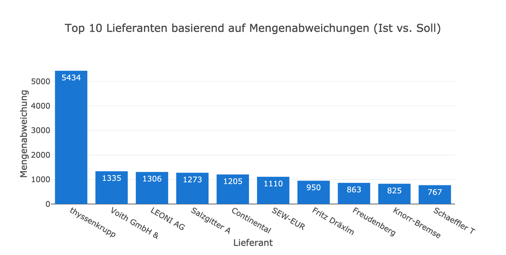

```python
display(Image(filename="../reports/images/top10_mengeabweichung_bar.png", width=600, height=100))
```

### Top 10 Risiko-Materialien basierend auf Mengenabweichungen

Materialien wie A6001779 und A2010580 zeigen die höchsten Mengenabweichungen, was potenzielle Produktionsausfälle bedeuten könnte.

**Interpretation** Diese Materialien sind besonders kritisch, da unzureichende Mengen die Produktionssicherheit gefährden können.

**Handlungsempfehlung** Strategische Sicherheitsbestände für diese Materialien anlegen.

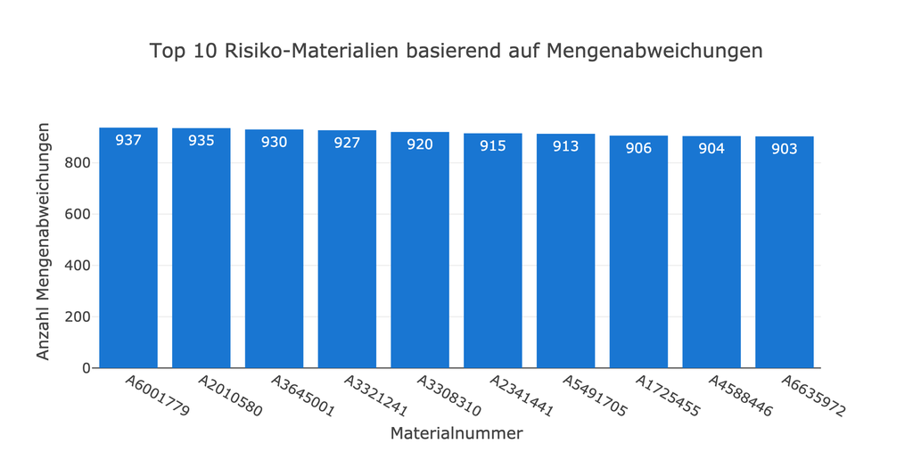

```python
display(Image(filename="../reports/images/top10_mengenabweichung_mat_bar.png", width=600, height=200))
```

### Über- und Unterlieferungen nach Land

**Handlungsempfehlung** Prognosen und Planungsprozesse für diese Regionen anpassen.

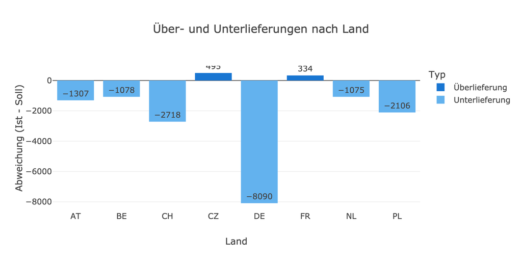

```python
display(Image(filename="../reports/images/ueber_unterlieferung_land_bar.png", width=600, height=200))
```

```python
!jupyter nbconvert --to html report_explanation_content_v2.ipynb
```